# The Lithium Standoff: Geopolitics, Ecology, and Physics

A field report on the minerals, bottlenecks, and environmental trade-offs behind the battery transition

Author

Ryan Lafferty

Published

May 12, 2026

# I. The Geopolitical Bottleneck

Scheyder (2023) identifies two critical choke points in the Western supply chain: **Permitting Speed** and **Refining Capacity**.

## 1. The “Time Tax” on Mining

While Australia and Canada function as “fast lanes” for resource extraction, the United States permitting process acts as a bottleneck. According to Scheyder (2023), US mine permitting averages 7-10 years compared to 2-3 years in peer nations. A 2023 study in *Science of the Total Environment* examining 72 proposed US lithium sites provides peer-reviewed context for the regulatory complexity driving these delays (“Potential Impacts of Proposed Lithium Extraction on Biodiversity and Conservation in the Contiguous United States” 2023).

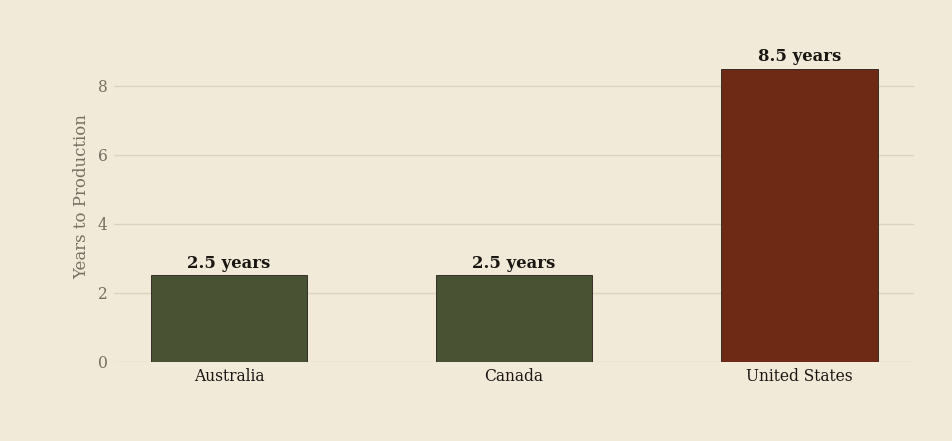

Figure 1: Average Mine Permitting Times (Years). Source: Scheyder (2023), investigative journalism. Peer-reviewed regulatory context: Science of the Total Environment (2023).

**NoteKey Finding**

As shown in Figure 1, the US takes **3-4x longer** to permit a lithium mine than Australia or Canada. This regulatory gap is a strategic vulnerability in the energy transition (Scheyder 2023).

**Data source:** Permitting time estimates are from investigative journalism (Scheyder 2023), not peer-reviewed research. The 72-site regulatory analysis in “Potential Impacts of Proposed Lithium Extraction on Biodiversity and Conservation in the Contiguous United States” (2023) provides peer-reviewed evidence for the structural causes of US permitting delays.

## 2. The Refining Monopoly

While lithium is found globally, the capacity to turn it into battery-grade chemicals is centralized. China accounts for almost two-thirds of the world’s lithium processing, while only **2.1% is refined in the US**. Beyond lithium, China controls **75% of cobalt processing**, **95% of manganese capacity**, and nearly all graphite capacity (APM Research Lab 2024).

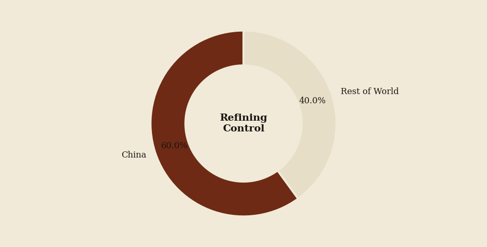

Figure 2: Global Lithium Refining Capacity Share. Source: APM Research Lab (2024) citing Reuters. Industry/gray literature.

**ImportantStrategic Risk**

Figure 2 shows that China controls **60%** of global lithium refining capacity. Even if the West mines more lithium, it still depends on Chinese processing infrastructure to produce battery-grade material (Scheyder 2023).

**Data source:** Refining capacity share from APM Research Lab (2024) citing Reuters (APM Research Lab 2024). This represents processing/refining capacity, not raw material extraction. Note: this is industry reporting (gray literature), not peer-reviewed data.

## 3. Global Reserves: Where the Lithium Actually Is

The geopolitical map has shifted. South America’s “Lithium Triangle” holds the largest reserves, but the US has moved up significantly following the Salton Sea discovery – the U.S. Department of Energy revealed the region contains over **3,400 kilotons** of lithium, enough for over 375 million EV batteries (U.S. Department of Energy 2024; U.S. Geological Survey 2025).

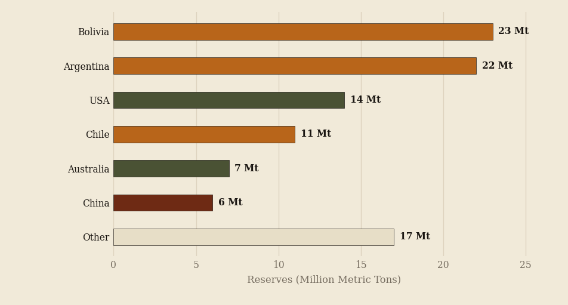

Figure 3: Global Lithium Reserves by Country (Million Metric Tons). Source: USGS Mineral Commodity Summaries (2025). Government data.

**TipThe Salton Sea Factor**

**Data source:** USGS Mineral Commodity Summaries (U.S. Geological Survey 2025). Government data, updated annually. Salton Sea figures from DOE (U.S. Department of Energy 2024).

## 4. Production vs. Reserves: The Extraction Gap

Global lithium production increased **18% to approximately 240,000 tons** in 2024, up from 204,000 tons in 2023 (U.S. Geological Survey 2025). But the countries with the most lithium in the ground are not the ones pulling it out the fastest.

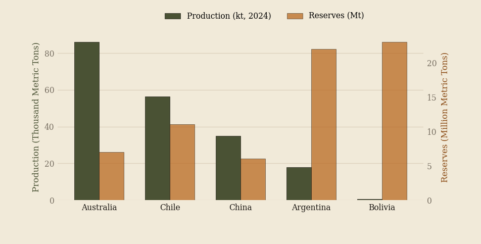

Figure 4: Top Lithium Producers (2024) vs. Reserves. Source: USGS Mineral Commodity Summaries (2025). Government data.

**WarningBolivia’s Paradox**

Bolivia sits on the world’s largest lithium reserves (**23 Mt**) yet produced only **600 metric tons** in 2024. Political instability, lack of infrastructure, and state control of mining have created a bottleneck that no amount of geology can fix (Scheyder 2023; U.S. Geological Survey 2025).

# II. Scientific Literature: The Hidden Trade-offs

Recent high-impact studies reveal that “green” technology often involves complex environmental swaps.

## 5. Direct Lithium Extraction (DLE) vs. Brine Ponds

A 2023 review in *Nature Reviews Earth & Environment* (IF: 42.7) (Vera et al. 2023) found that while DLE technologies achieve **95%+ lithium recovery rates**, only **30% have been tested on real-world brines** – the rest are lab-scale only.

A 2024 study in *Environmental Science & Technology* (IF: 11.4) (“Direct Lithium Extraction: Environmental Life Cycle Assessment” 2024) and *Resources Conservation & Recycling* (“Life Cycle Comparison of Lithium Extraction Methods” 2024) highlights a massive divergence: DLE saves land but costs carbon.

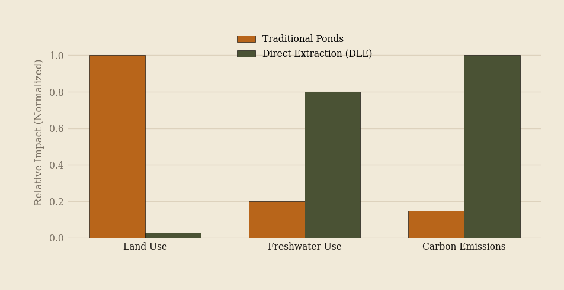

Figure 5: The Environmental Trade-off: DLE vs. Evaporation Ponds. Sources: ES&T (2024); Resources, Conservation and Recycling (2024); Vera et al., Nature Reviews Earth & Environment (2023). All peer-reviewed. Values normalized to 1.0 for comparative visualization.

**WarningThe Trade-off**

Figure 5 shows there is no free lunch. DLE dramatically reduces land footprint but shifts the burden to carbon emissions. A 2025 study in *ES&T* (IF: 11.4) found that environmental impacts vary **4x for GHG emissions** and an astonishing **2,885x for land use** between different mining sites globally. Furthermore, 56-68% of environmental impacts generated in mining countries are embodied in internationally traded lithium flows (Liu et al. 2025).

**Data source:** Synthesized from *Environmental Science & Technology* (2024) and *Resources, Conservation and Recycling* (2024) comparative studies, with additional context from Vera et al. (2023). All peer-reviewed. Values normalized to 1.0 for visualization; actual impacts vary by location and specific extraction technology.

## 6. The Carbon Cost of Lithium

Extraction is energy-intensive. According to MIT Climate Lab, one ton of mined lithium emits nearly **15 tonnes of CO2** (MIT Climate Lab 2024). Hard rock mining can reach **20.4 tonnes CO2** per tonne of lithium. But this varies dramatically by method.

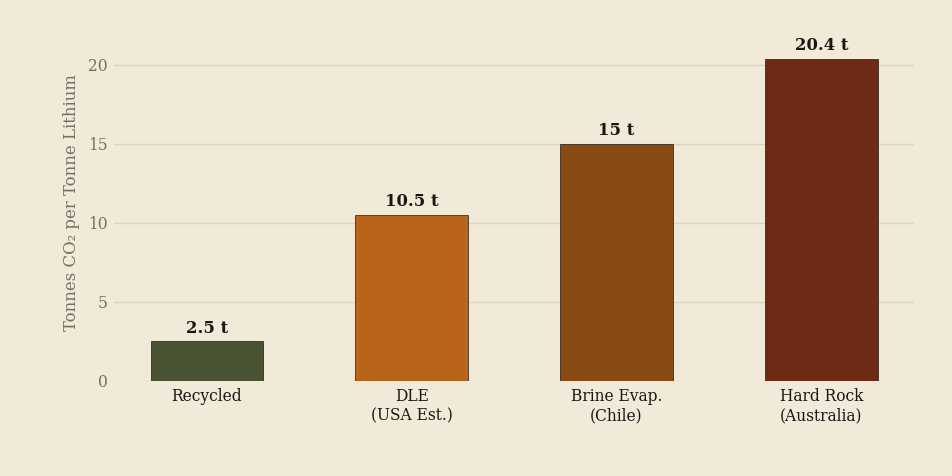

Figure 6: Carbon Intensity by Extraction Method (Tonnes CO2 per Tonne Li). Sources: MIT Climate Lab (2024, gray literature) for brine baseline; industry estimates for DLE and recycling; peer-reviewed literature for hard rock.

**TipThe Recycling Dividend**

Figure 6 shows that recycled lithium produces roughly **8x less CO2** than hard rock mining. This is the strongest argument for building recycling infrastructure now, before the first wave of EV batteries reaches end-of-life.

**Data source:** Brine evaporation baseline (~15 t CO2) from MIT Climate Lab (MIT Climate Lab 2024) (gray literature, not peer-reviewed). Hard rock figure (~20.4 t) from industry analysis. DLE and recycling estimates are modeled projections. The Liu et al. (2025) study (peer-reviewed, IF: 11.4) confirms that carbon intensity varies significantly by site.

## 7. The Physics of Future Density

Battery technology is advancing on two fronts. A 2025 Tsinghua University breakthrough published in *Nature* (IF: 64.8) achieved **604 Wh/kg** gravimetric and **1,027 Wh/L** volumetric energy density in solid-state cells – more than twice today’s top commercial batteries at ~255 Wh/kg (Tsinghua University 2025). A separate study in *Nature Sustainability* confirmed batteries exceeding 500 Wh/kg (“Batteries Achieving Specific Energy Exceeding 500 Wh/Kg” 2025). Meanwhile, lithium-sulfur batteries offer a theoretical ceiling of **2,600 Wh/kg**, roughly 10x current Li-ion, according to *Communications Materials* (IF: 7.9) (“Assessing the Practical Feasibility of Solid-State Lithium–Sulfur Batteries” 2025).

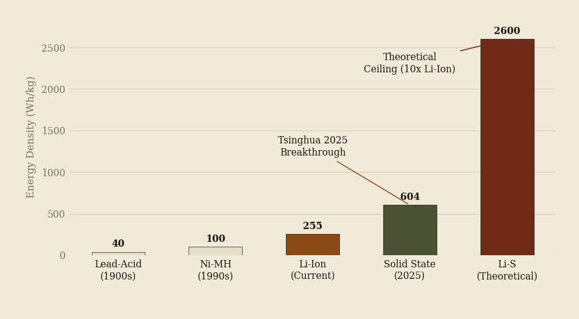

Figure 7: Evolution of Battery Energy Density (Wh/kg). Sources: Lead-acid and Ni-MH are industry standard benchmarks. Current Li-Ion: Communications Materials (2025), peer-reviewed. Solid-state: Nature (2025), Tsinghua University, peer-reviewed. Li-S theoretical: Communications Materials (2025), peer-reviewed.

**NoteTwo Horizons**

**Near-term (2025-2030):** Solid-state batteries at 604 Wh/kg are real – prototyped and measured, published in *Nature* (Tsinghua University 2025). Commercialization is the challenge. **Long-term (2030+):** Lithium-sulfur at 2,600 Wh/kg remains theoretical (“Assessing the Practical Feasibility of Solid-State Lithium–Sulfur Batteries” 2025), but if achieved would make EVs lighter than gasoline cars.

**Data source:** Historical values (lead-acid, Ni-MH) are industry standard benchmarks, not from the cited journal articles. Current Li-ion (~255 Wh/kg) and Li-S theoretical from *Communications Materials* (2025) (peer-reviewed). Solid-state from *Nature* (2025) (peer-reviewed). Additional confirmation from *Nature Sustainability* (2025).

# III. The Recycling Imperative

Currently only **1-3% of lithium** is recovered globally from recycled batteries, mainly due to high costs. Yet a 2025 *Nature Communications* (IF: 16.6) study found that a minimum **84% collection rate** is needed to stabilize lithium supply by 2060 (“Lithium-Ion Battery Recycling Relieves the Threat to Material Scarcity” 2025).

## 8. Recovery Rates by Recycling Method

Not all recycling is equal. The three main approaches recover different materials at very different rates.

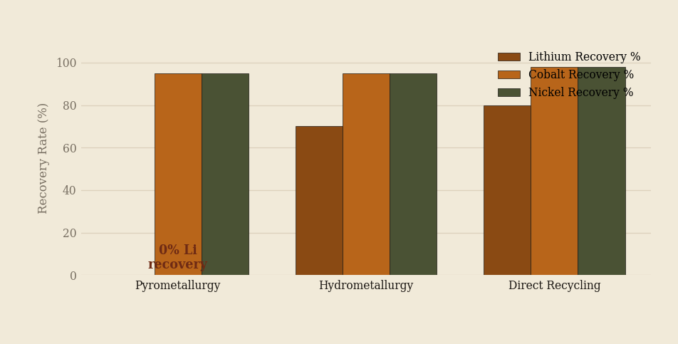

Figure 8: Battery Recycling Recovery Rates by Method. Source: Industry data and peer-reviewed literature. Recovery rates represent current technological capabilities.

**ImportantThe Pyrometallurgy Problem**

Figure 8 reveals a critical flaw: **pyrometallurgy recovers zero lithium**. It’s the cheapest method but treats lithium as slag waste. The industry must shift toward hydrometallurgy and direct recycling to close the loop (“Lithium-Ion Battery Recycling Relieves the Threat to Material Scarcity” 2025).

**Data source:** Recovery rates from industry analysis and *Nature Communications* (2025) (peer-reviewed, IF: 16.6). The 84% collection rate target is a modeled finding from the same study.

## 9. The Recycling Market Outlook

The global lithium battery recycling market is valued at **$5.4-16.2 billion** (2024) and projected to reach **$24-47 billion by 2032**, growing at a **17-20.6% CAGR**. The EU has mandated that EV batteries must contain a minimum **6% recycled lithium and nickel by 2030** (European Union 2023).

# IV. Demand Outlook

## 10. What’s Eating the Lithium?

In 2024, **87% of global lithium** went to batteries. The remaining 13% was split across ceramics, lubricants, and industrial applications (U.S. Geological Survey 2024).

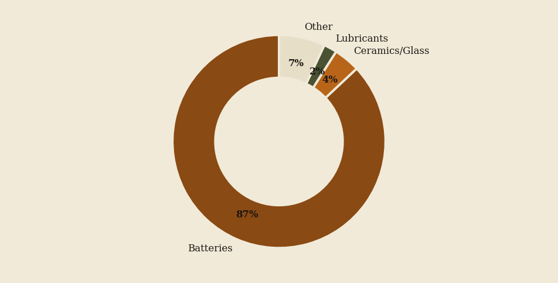

Figure 9: Global Lithium Demand by Application (2024). Source: USGS Mineral Commodity Summaries (2024, 2025). Government data.

**NoteDemand Scale**

An average EV uses **8 kg of lithium** (a Tesla Model S uses 62.6 kg). Global demand is forecast to reach **1 million metric tons by 2025** and **surpass 2 million tons by 2030** (U.S. Geological Survey 2025).

# V. Summary Data Tables

## Water Intensity Reference

*Multiple sources converge on these ranges* (U.S. Geological Survey 2025; “Water Footprint Assessment of Lithium Production in the Salar de Atacama” 2024; Vera et al. 2023; Wetlands International Europe 2023; “Water Consumption in Lithium Mining: A Comparative Analysis” 2024)

| Extraction Method | Water Usage (per Tonne Li) | Source Type | Primary Region |
| --- | --- | --- | --- |
| **Brine Ponds** | ~500,000 gal / 2M liters | Multiple (industry + gray lit.) | Chile/Argentina |
| **Hard Rock** | 100,000-300,000 gal | Industry analysis | Australia |
| **DLE** | Up to 81% reduction vs. conventional | Industry analysis | USA (Proposed) |
| **Salar de Atacama** | 442 m³ world equiv. (AWARE) | Peer-reviewed (JCP, IF: 11.1) | Chile |

## Carbon Intensity Reference

| Source | CO2 per Tonne Li | Source Type |
| --- | --- | --- |
| **Recycled** | ~2.5 tonnes | Industry estimate |
| **DLE** | ~10.5 tonnes | Modeled projection |
| **Brine Evaporation** | ~15 tonnes | Gray lit. (MIT Climate Lab) |
| **Hard Rock Mining** | ~20.4 tonnes | Industry analysis |

*Note: MIT Climate Lab baseline (~15 t) is gray literature (MIT Climate Lab 2024). The Liu et al. (2025) ES&T study (peer-reviewed, IF: 11.4) confirms significant site-by-site variation but does not provide single-point estimates.*

## Key Statistics at a Glance

[output not shown]

## Source Quality Legend

| Tag | Meaning | Examples in This Report |
| --- | --- | --- |
| **Peer-rev.** | Published in peer-reviewed journals with editorial review | Nature, ES&T, Nature Comm., Comm. Materials, NREE |
| **Gov.** | Government agency data, publicly audited | USGS, DOE, EU Regulation |
| **Gray lit.** | Industry reports, think tanks, journalism – not peer-reviewed | MIT Climate Lab, APM Research Lab, Reuters, Scheyder (2023) |
| **Industry** | Corporate/trade analysis | Lithium Harvest, SolarTech, market research firms |

## References

APM Research Lab. 2024. “Lithium Processing and Refining: Global Capacity Analysis.” APM Research Lab, citing Reuters.

“Assessing the Practical Feasibility of Solid-State Lithium–Sulfur Batteries.” 2025. *Communications Materials*. https://doi.org/10.1038/s43246-025-00918-9.

“Batteries Achieving Specific Energy Exceeding 500 Wh/Kg.” 2025. *Nature Sustainability*.

“Direct Lithium Extraction: Environmental Life Cycle Assessment.” 2024. *Environmental Science & Technology*.

European Union. 2023. “EU Battery Regulation 2023/1542.” Official Journal of the European Union.

“Life Cycle Comparison of Lithium Extraction Methods.” 2024. *Resources, Conservation and Recycling*.

“Lithium-Ion Battery Recycling Relieves the Threat to Material Scarcity.” 2025. *Nature Communications*.

Liu, W. et al. 2025. “Robust Assessments of Lithium Mining Impacts Embodied in Global Supply Chain Require Spatially Explicit Analyses.” *Environmental Science & Technology* 59 (14): 7081–94. https://doi.org/10.1021/acs.est.4c12749.

MIT Climate Lab. 2024. “Lithium Mining for EVs: Sustainability Considerations.” APM Research Lab.

“Potential Impacts of Proposed Lithium Extraction on Biodiversity and Conservation in the Contiguous United States.” 2023. *Science of the Total Environment*.

Scheyder, Ernest. 2023. *The War Below: Lithium, Copper, and the Global Battle to Power Our Lives*. New York: Atria Books.

Tsinghua University. 2025. “Solid-State Battery Achieving 604 Wh/Kg Gravimetric Energy Density.” *Nature*.

U.S. Department of Energy. 2024. “Salton Sea Lithium Resource Assessment.” DOE Report.

U.S. Geological Survey. 2024. “Mineral Commodity Summaries 2024: Lithium.” USGS Annual Report. https://pubs.usgs.gov/periodicals/mcs2024/mcs2024-lithium.pdf.

———. 2025. “Mineral Commodity Summaries 2025: Lithium.” USGS Annual Report. https://pubs.usgs.gov/periodicals/mcs2025/mcs2025-lithium.pdf.

Vera, M. L., W. R. Torres, C. I. Galli, A. Chagnes, and V. Flexer. 2023. “Environmental Impact of Direct Lithium Extraction from Brines.” *Nature Reviews Earth & Environment* 4: 149–65. https://doi.org/10.1038/s43017-022-00387-5.

“Water Consumption in Lithium Mining: A Comparative Analysis.” 2024. Lithium Harvest / SolarTech Industry Analysis.

“Water Footprint Assessment of Lithium Production in the Salar de Atacama.” 2024. *Journal of Cleaner Production*. https://doi.org/10.1016/j.jclepro.2024.140848.

Wetlands International Europe. 2023. “Water Impacts of Lithium Brine Extraction.” Wetlands International.

Further Reading

For the geopolitics behind the maps, read Ernest Scheyder’s *The War Below* on the Geoglypha reading shelf.